# E013 drawing CgPho4-ScPho4 alignment

Bin He

2024-03-01 updated 2024-03-06

```r
require(tidyverse)
require(cowplot)
require(seqinr)
#require(ggtext)
#require(RColorBrewer)
```

```r
old <- theme_set(theme_bw(base_size = 16))
```

# Goal

Create illustrative figures to visualize the level of similarity between ScPho4 and CgPho4, as well as annotations.

# Process alignment

The idea is to construct a table from the MSA so we can map the positions within each Pho4 ortholog to a common coordinate based on the alignment. We will incorporate alignment scores calcucated by Jalview as additional columns. Later, we can map other external annotation scores, such as PADDLE prediction, onto the same coordinate system.

## Read alignment

Using the `seqinr` package

```r
msa <- read.alignment(
  file = "../input/Pho4-alignment/20201124-ScPho4-CgPho4-aa-aln.fa",
  format = "fasta")
tmp <- str_split(msa$seq, pattern = "", simplify = FALSE)
names(tmp) <- msa$nam
aln <- tibble(
  pos_aln = 1:length(tmp$Scer),
  char_Scer = toupper(tmp$Scer),
  pos_Scer = cumsum(char_Scer != "-"),
  char_Cgla = toupper(tmp$Cgla),
  pos_Cgla = cumsum(char_Cgla != "-")
)
```

## Read Jalview score

```r
jalview.score <- read.csv("../input/Pho4-alignment/20240301-ScPho4-CgPho4-jalview-score.csv")
```

## Calculate the average score per region

Encode the breakpoints

```r
r.label <- paste0("R", 1:5)
br = list(
  Scer = c(0, 42, 99, 176, 242, 312),
  Cgla = c(0, 44, 112, 282, 458, 533),
  aln = c(0, 44, 113, 294, 470, 547)
)
# make a tibble containing the region definition
regions <- tibble(
  name = r.label,
  begin_Scer = head(br$Scer + 1, -1),
  end_Scer = tail(br$Scer, -1),
  begin_Cgla = head(br$Cgla + 1, -1),
  end_Cgla = tail(br$Cgla, -1),
  begin_aln = head(br$aln + 1, -1),
  end_aln = tail(br$aln, -1)
)
```

Calculate the average scores

| region | Conservation | Quality |
| --- | --- | --- |
| R1 | 7.818182 | 0.3961985 |
| R2 | 5.185185 | 0.3082359 |
| R3 | 3.224852 | 0.2942305 |
| R4 | 3.062500 | 0.2888073 |
| R5 | 7.896104 | 0.4107778 |

## Plot alignment line graph

[figure not shown]

```r
lw = 0.6
p <- dat %>%
  mutate(
    pos_aln = pos_aln - 1/2*max(pos_aln),
    pos_Scer = ifelse(char_Scer == "-", NA, pos_Scer - 1/2*max(pos_Scer)),
    pos_Cgla = ifelse(char_Cgla == "-", NA, pos_Cgla - 1/2*max(pos_Cgla))
  ) %>%
  ggplot() +
  geom_tile(aes(x = pos_aln, y = 1.5, height = 0.1, fill = Conservation),
            width = 1.5, linewidth = 0) +
  geom_segment(aes(x = pos_aln, xend = pos_Scer, y = 1.55, yend = 1.95), color = "gray90") +
  geom_segment(aes(x = pos_Cgla, xend = pos_aln, y = 1.05, yend = 1.45), color = "gray90") +
  geom_rect(data = regions,
            aes(xmin = begin_Scer - 312/2, xmax = end_Scer - 312/2,
                ymin = 1.95, ymax = 2.15),
            fill = "forestgreen", color = "gray90", linewidth = lw) +
  geom_rect(data = regions,
            aes(xmin = begin_Cgla - 533/2, xmax = end_Cgla - 533/2,
                ymin = 0.85, ymax = 1.05),
            fill = "steelblue2", color = "gray90", linewidth = lw) +
  geom_segment(data = as_tibble(br),
               aes(x = aln - 547/2, xend = Scer - 312/2,  y = 1.55, yend = 1.95),
               color = "gray40", linewidth = lw, linetype = 3) +
  geom_segment(data = as_tibble(br),
               aes(xend = aln - 547/2, x = Cgla - 532/2,  y = 1.05, yend = 1.45),
               color = "gray40", linewidth = lw, linetype = 3) +
  #scale_y_continuous(expand = expansion(mult = 0.3)) +
  scale_fill_distiller(palette = "Greys", direction = 1, breaks = c(-0.1,5,10,12))
p +
  theme_cowplot() +
  theme(legend.position = "none",
        axis.line = element_blank(),
        axis.text = element_blank(),
        axis.title = element_blank(),
        axis.ticks = element_blank())
```

```r
ggsave(filename = "../output/20240302-ScPho4-CgPho4-align-region-graph.png",
       width = 5, height = 2)
```

## Add activation domain prediction result

Read data. Note the following instructions from the PADDLE ipython notebook script:

> Run predictions on all 53 amino acid long tiles across the protein. This function requires matching protein sequence and secondary structure scores. Returns a Numpy array of size (protein_length-52) which gives the predicted activation Z-score for the 53aa tiles starting at positions 1, 2, 3, …, protein_length-52. High-strength ADs can be called by finding >=5 consecutive positions with Z-score > 6. Medium-strength ADs can be called by finding >=5 consecutive positions with Z-score > 4.

```r
paddle.Sc <- read_csv("../input/paddle-prediction/20240305-ScPho4-PADDLE-prediction.csv") %>%
  mutate(
    strong = Z_score >= 6,
    medium = Z_score >= 4
  )
# extend the prediction score to the N-terminus and C-terminus
paddle.Sc <- paddle.Sc[c(rep(1, 26), 1:nrow(paddle.Sc), rep(nrow(paddle.Sc), 26)),] %>%
  mutate(Pos = 1:n())


paddle.Cg <- read_csv("../input/paddle-prediction/20240305-CgPho4-PADDLE-prediction.csv") %>%
  mutate(
    strong = Z_score >= 6,
    medium = Z_score >= 4
  )
# extend the prediction score to the N-terminus and C-terminus
paddle.Cg <- paddle.Cg[c(rep(1, 26), 1:nrow(paddle.Cg), rep(nrow(paddle.Cg), 26)),] %>%
  mutate(Pos = 1:n())
```

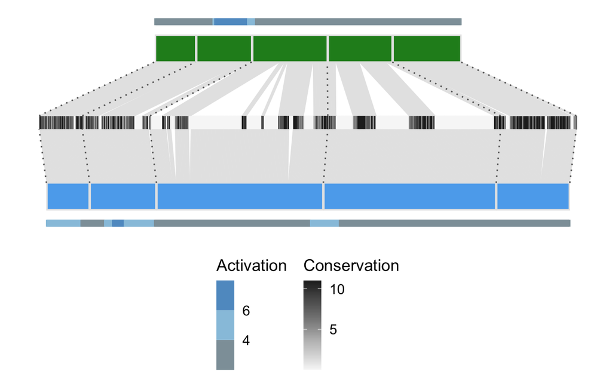

```r
act.colors <- RColorBrewer::brewer.pal(n = 3, name = "Blues")
act.colors[1] = "gray50"
p1 <- p +
  new_scale_fill() +
  geom_tile(data = paddle.Sc,
            aes(x = Pos - 312/2, y = 2.25, height = 0.05, fill = Z_score),
            width = 2, linewidth = 0) +
  geom_tile(data = paddle.Cg,
            aes(x = Pos - 533/2, y = 0.75, height = 0.05, fill = Z_score),
            width = 2, linewidth = 0) +
  scale_fill_stepsn("Activation", colors = act.colors,
                       breaks = c(-0.5, 4, 6, 10))

p1 <- p1 + theme_cowplot() +
  theme(legend.position = "bottom",
        legend.direction = "vertical",
        legend.box = "horizontal",
        legend.justification = "center",
        axis.line = element_blank(),
        axis.text = element_blank(),
        axis.title = element_blank(),
        axis.ticks = element_blank())

print(p1)
```

for the paper

```r
ggsave(filename = "../output/20240306-ScPho4-CgPho4-align-region-with-activation.png",
       width = 5, height = 3.5)
```